layout: factors title: "Factors Examples" permalink: /

# Factors are cool

I surveyed 10 biologists about their favorite nucleic acid and put their responses into a vector.

```r
# Hard coding the survey results.
# R allows you to split things between parentheses onto multiple lines
# to make it easier to read.
favorite_nucleic_acid <- c("T", "A", "U", "U", "A",
                           "C", "T", "U", "A", "U")
```

We can summarize this data with the table function

```r
table(favorite_nucleic_acid)
```

```
favorite_nucleic_acid
A C T U
3 1 2 4
```

We can also take a look at a barplot using graphing functions we’ll learn more about later in the course

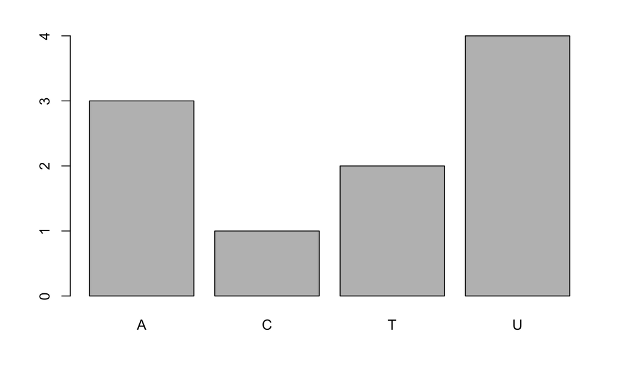

```r
barplot(table(favorite_nucleic_acid))
```

R counted the number of responses, but as biologists, we know that there’s one other nucleotide that no one picked. This creates an awkward situations where people might think we don’t know Guanine exists. Using a factor, we can let R know that G was a possible option.

```r
# Convert to factor and giving it a levels argument
factor_favorite_nucleic_acid <- factor(favorite_nucleic_acid,
                                      levels=c("A", "C", "G", "T", "U"))

# Summarizing the data with table()
table(factor_favorite_nucleic_acid)
```

```
factor_favorite_nucleic_acid
A C G T U
3 1 0 2 4
```

```r
# A more common way of summarizing factors:
# summary(factor_favorite_nuceic_acid)
```

With a barplot

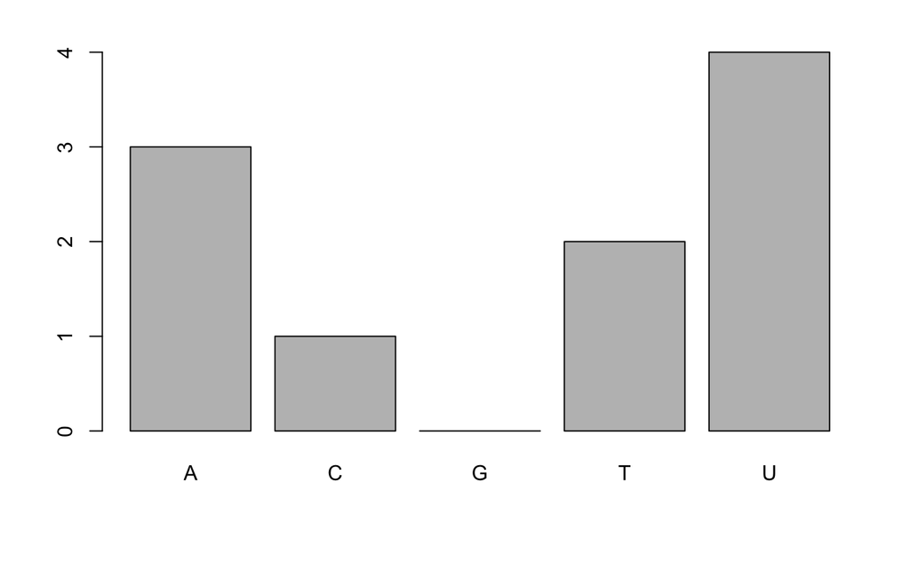

```r
# create a barplot with base R plotting
barplot(table(factor_favorite_nucleic_acid))
```

Now R knows that G exists, but that no one likes it :(

```r
# Survey results as a vector
favorite_day <- c("Saturday", "Tuesday", "Saturday", "Saturday", "Wednesday",
                     "Sunday", "Thursday", "Friday", "Friday")

# Summarize with table() function
table(favorite_day)
```

```
favorite_day
   Friday  Saturday    Sunday  Thursday   Tuesday Wednesday
        2         3         1         1         1         1
```

Checking out on a barplot

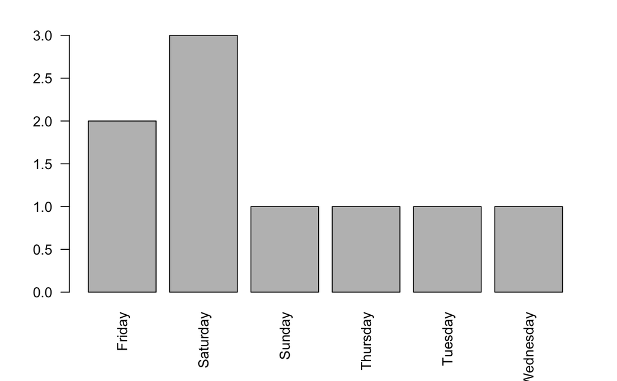

```r
# create a barplot and rotate labels for readability
barplot(table(favorite_day), las=2)
```

2 problems now. We’re missing Monday (no one likes Mondays). But also, we know that there’s an order to these days. So it’s weird and confusing to see them jumbled like this.

Factors can fix this!

```r
# convert to factor with ordered levels
factor_favorite_day <- factor(favorite_day,
                                 ordered=TRUE,
                                 levels=c("Monday", "Tuesday", "Wednesday",
                                          "Thursday", "Friday", "Saturday", "Sunday"))
#output a table
table(factor_favorite_day)
```

```
factor_favorite_day
   Monday   Tuesday Wednesday  Thursday    Friday  Saturday    Sunday
        0         1         1         1         2         3         1
```

as a barplot

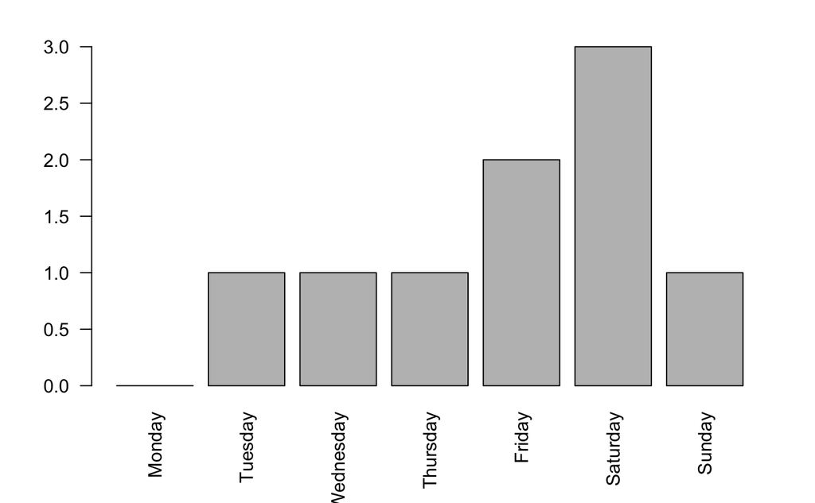

```r
# create a barplot and rotate labels for readability
barplot(summary(factor_favorite_day), las=2)
```